# St. John’s College (Annapolis, MD)

### Students from US

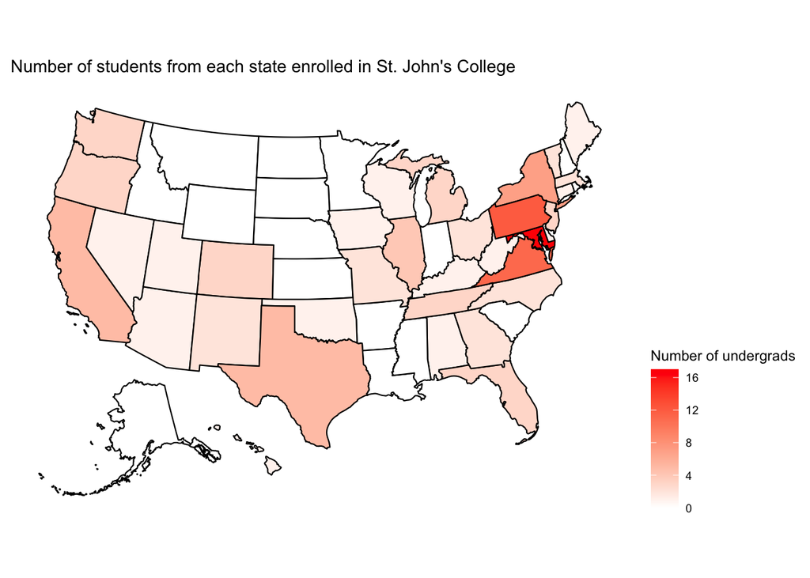

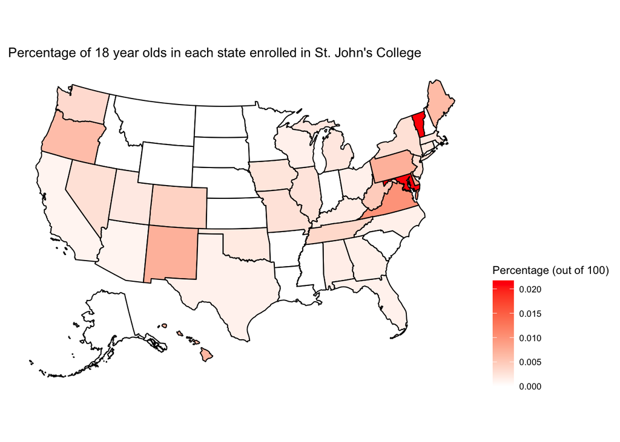